# MUSA 508 Final

Analyzing delays on New Jersey Transit & Amtrak

Benjamin She https://github.com/bensh3/ (Limited Express LLC) , Lechuan Huang https://github.com/hlechuan/ (Limited Express LLC)  
2021-12-17

## Background

[figure not shown]

New Jersey Transit Northeast Corridor Line train at New Brunswick

The lifeblood of any large metropolitan city is in its transit, but it’s a dual-edged sword: not properly anticipating and handling train delays could be disastrous for the region economically and socially. For New Jersey, the densest state in the United States, having a statewide regional rail network is a particularly difficult affair. Developed over 190 years through multiple private railroad companies, the New Jersey Transit network today is still quite vulnerable to delays and outright cancellations, causing widespread frustration and disinterest among the public for transit. Especially as the pandemic has suggested the long-term viability of remote/hybrid work, people more than ever have the option to skip riding the train against their will, and transit agencies must must take the initiative through opportunities like the Building Back Better infrastructure bill to get the ridership they cannot now take for granted.

[figure not shown]

Delay headlines

At the same time, there has been a movement among more transit agencies to expose more of their collected data to the public, whether pre-existing or newly captured. Analysts from inside and outside the agency can develop new rider metrics and analytics based on this historical performance, and eventually develop visualizations and dashboards both for their own purposes and as tools for savvy commuters.

In this report, our firm Limited Express was retained by NJ Transit to develop a proof-of-concept model, called NJT onTrack, that serves this dual purpose for the Rail Operations division. The eventual aim is to develop both a feature metric integrated in the existing NJ Transit app to predict and display potential delays before they occur, and build an analytical dashboard that displays historical train performance, service levels, and delay indicators. Using a linear regression model with temporal-spatial lag predictors, it is hoped that as delay predictions improve, they can eventually feed back into schedule planning and capital infrastructure investment to reduce delay hotspots altogether, both in time (time of day, day of week) and in space (particular bottlenecks or slow zones).

## Setup

```r
library(caret)
library(data.table)
library(gganimate)
library(ggcorrplot)
library(gridExtra)
library(hms)
library(leaflet)
library(lubridate)
library(patchwork)
library(riem)
library(scales)
library(sf)
library(lwgeom)
library(tidyverse)
library(tidytransit)

source("https://raw.githubusercontent.com/urbanSpatial/Public-Policy-Analytics-Landing/master/functions.r")
`%ni%` <- Negate(`%in%`)
```

```r
int.ampeak <- interval(as_hms("06:00:00"),as_hms("10:00:00"))
int.midday <- interval(as_hms("10:00:01"),as_hms("16:00:00"))
int.pmpeak <- interval(as_hms("16:00:01"),as_hms("19:00:00"))
int.evening <- interval(as_hms("19:00:01"),as_hms("23:59:59"))
int.overngt <- interval(as_hms("00:00:00"),as_hms("05:59:59"))
```

## Kaggle data wrangling

```r
invalid <- rbind(read_csv("delay/invalid_trains.csv"),read_csv("delay/invalid_trains_05-01-19_05-18-20.csv"))
invalid$date <- invalid$date %>% str_replace_all("_","-") %>% as.Date()

delay_files <- list.files("delay",pattern="^2019")
delay <- lapply(paste0('delay/',delay_files),read_csv) %>%
  map(anti_join,invalid,by=c("date","train_id"))

names(delay) <- stringr::str_replace(delay_files, pattern = ".csv", replacement = "")
```

We also load the GTFS data for verifying purposes, and to get geographic stop time data

```r
njt <- read_gtfs("gtfs_njt.zip")
njt_sf <- gtfs_as_sf(njt)
```

Here we begin to wrangle the delay data into a single dataset. A number of tasks are done: - Agency was filtered for NJ transit, and all imcomplete stops removed, including trains noted as invalid - Each stop time associated with a time period through the day, from AM peak to overnight - A dummy variable for noting if the stop time was on the weekday or weekend - Assessing the route direction of the train associated the stop time; eastbound is towards New York Penn, Hoboken, or Atlantic City, and westbound the opposite direction - Defining the absolute ordinal stop sequence of each route so numbers are consistent even when express trains skip stations - A dummy variable for assessing if the train is over 6 minutes late at the stop time

```r
njtlines <- rbindlist(delay %>% tidyselect:::select(starts_with('2019'))) %>%
  filter(type == 'NJ Transit') %>%
  filter(line %in% c('Northeast Corrdr','No Jersey Coast','Atl. City Line')) %>%
  arrange(date,line,train_id,stop_sequence) %>%
  filter(complete.cases(.)) %>%
  mutate(period = case_when(
    ymd_hms(paste0('1970-01-01',str_sub(scheduled_time,12))) %within% int.ampeak  ~ "AM peak",
    ymd_hms(paste0('1970-01-01',str_sub(scheduled_time,12))) %within% int.midday  ~ "Midday",
    ymd_hms(paste0('1970-01-01',str_sub(scheduled_time,12))) %within% int.pmpeak  ~ "PM peak",
    ymd_hms(paste0('1970-01-01',str_sub(scheduled_time,12))) %within% int.evening  ~ "Evening",
    ymd_hms(paste0('1970-01-01',str_sub(scheduled_time,12))) %within% int.overngt  ~ "Overnight"
  )) %>% mutate(isWkdy = ifelse(wday(date) %in% c(2,3,4,5,6),TRUE,FALSE)
   ) %>% mutate(direction = case_when(
    stop_sequence == 1 & from %ni% c('New York Penn Station','Hoboken','Atlantic City Rail Terminal') ~ 'eastbound',
    stop_sequence == 1 & from %in% c('New York Penn Station','Hoboken','Atlantic City Rail Terminal') ~ 'westbound'
  )) %>% fill(direction) %>%
  mutate(stop_seq_abs = as.numeric(factor(stop_sequence))) %>%
  mutate(isLate = if_else(delay_minutes >= 6,TRUE,FALSE))
```

We must also filter out faulty train runs that did not appear to record or change their timepoint when going from first to last station.

```r
first <- njtlines %>% group_by(date,train_id) %>% arrange(stop_sequence) %>% filter(row_number()==1) %>% rename('first_time' = 'actual_time') %>% select(date,train_id,first_time)

last <- njtlines %>% group_by(date,train_id) %>% arrange(-stop_sequence) %>% filter(row_number()==1) %>% rename('last_time' = 'actual_time') %>% select(date,train_id,last_time)

invalid2 <- first %>% left_join(last,by=c('date','train_id')) %>% filter(first_time == last_time)

njtlines <- njtlines %>% anti_join(invalid2,by=c('date','train_id')) %>% filter(delay_minutes <= 240)
```

The last variable we can derive from existing data is the lagged delay experienced at each train’s previous station. This station-based lag is an approximation of the “spatial lag” found in other purely spatial-based analyses.

```r
njtlines <- njtlines %>% group_by(date,train_id) %>% mutate(lagStation = dplyr::lag(delay_minutes,n=1,default=0))
```

## Exploratory analysis and visualization

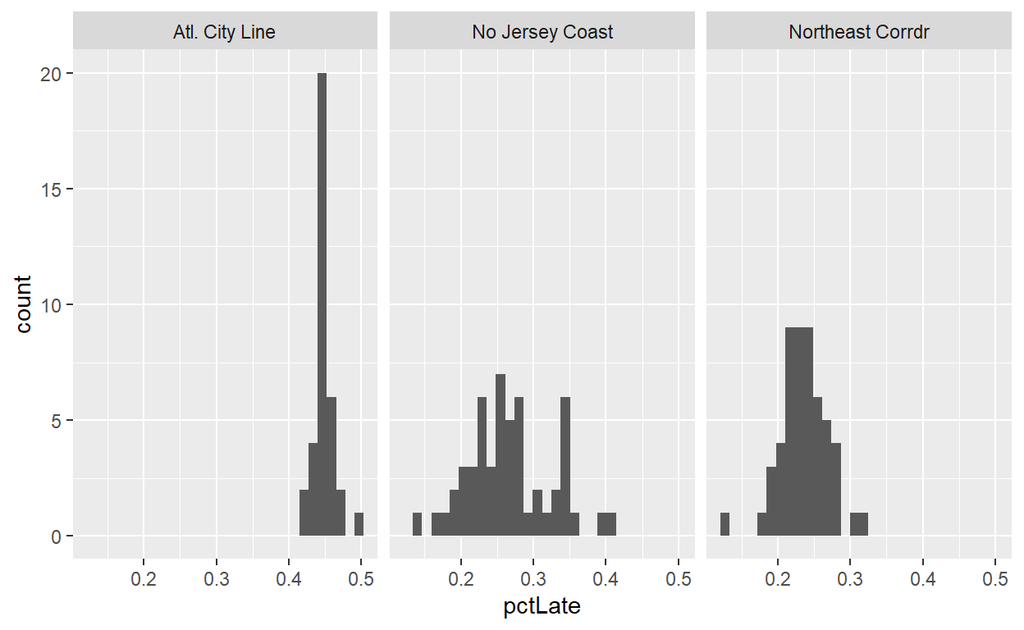

```r
njtlines %>% group_by(line,week(date)) %>%
  summarise(pctLate = sum(isLate)/sum(isLate %in% c(TRUE,FALSE))) %>%
  ggplot(aes(pctLate)) + geom_histogram() + facet_wrap(vars(line))
```

### Schedule deviance chart, faceted by time/direction of service

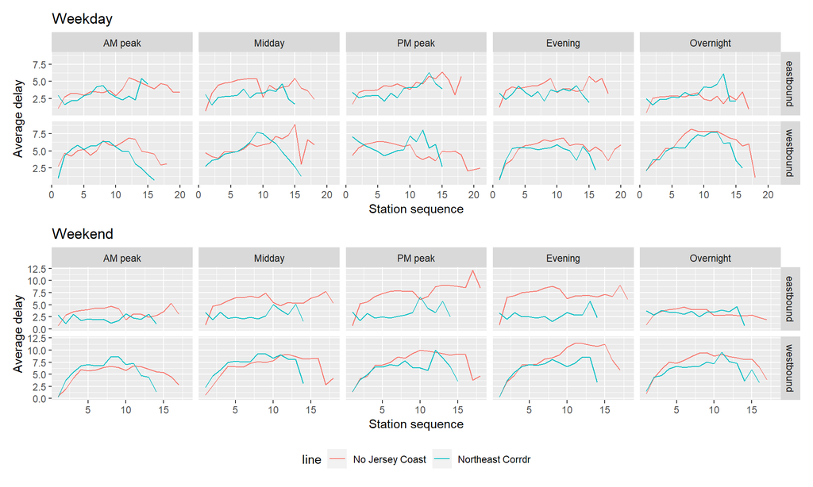

```r
  p1 <- njtlines %>% filter(isWkdy & line != "Atl. City Line") %>% group_by(line,direction,period,stop_seq_abs) %>%
    summarise(avgdelay = mean(delay_minutes)) %>%
    ggplot(aes(x=stop_seq_abs, y=avgdelay, color=line)) +
    geom_line() +
    facet_grid(direction ~ factor(period,levels=c("AM peak","Midday","PM peak","Evening","Overnight"))) +
    ggtitle('Weekday') + labs(x="Station sequence",y="Average delay") + theme(legend.position='none')
  p2 <- njtlines %>% filter(!isWkdy & line != "Atl. City Line") %>% group_by(line,direction,period,stop_seq_abs) %>%
    summarise(avgdelay = mean(delay_minutes)) %>%
    ggplot(aes(x=stop_seq_abs, y=avgdelay, color=line)) +
    geom_line() +
    facet_grid(direction ~ factor(period,levels=c("AM peak","Midday","PM peak","Evening","Overnight"))) +
    ggtitle('Weekend') + labs(x="Station sequence",y="Average delay") + theme(legend.position='bottom')

  p1 / p2
```

Compared to the other lines, we can see that the Atlantic City line has considerably higher baseline levels of delays. This is because in 2019, much of the ACRL was on maintenance due to ongoing positive train control signalling installation; the data snapshot here may not be indicative of future trends.

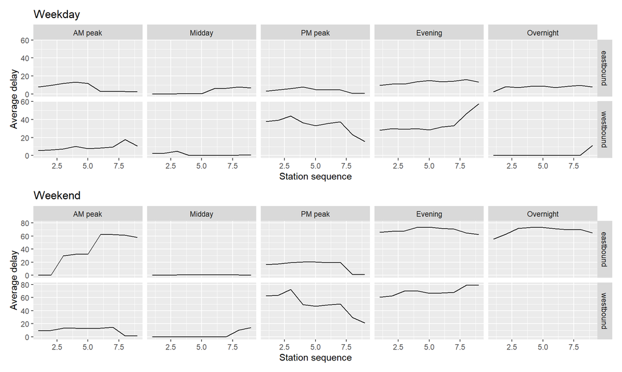

```r
  p1 <- njtlines %>% filter(isWkdy & line == "Atl. City Line") %>% group_by(direction,period,stop_seq_abs) %>%
    summarise(avgdelay = mean(delay_minutes)) %>%
    ggplot(aes(x=stop_seq_abs, y=avgdelay)) +
    geom_line() +
    facet_grid(direction ~ factor(period,levels=c("AM peak","Midday","PM peak","Evening","Overnight"))) +
    ggtitle('Weekday') + labs(x="Station sequence",y="Average delay") + theme(legend.position='none')
  p2 <- njtlines %>% filter(!isWkdy & line == "Atl. City Line") %>% group_by(direction,period,stop_seq_abs) %>%
    summarise(avgdelay = mean(delay_minutes)) %>%
    ggplot(aes(x=stop_seq_abs, y=avgdelay)) +
    geom_line() +
    facet_grid(direction ~ factor(period,levels=c("AM peak","Midday","PM peak","Evening","Overnight"))) +
    ggtitle('Weekend') + labs(x="Station sequence",y="Average delay") + theme(legend.position='bottom')

  p1 / p2
```

### Stringline diagram of one day’s service

To accurately display the stringline we first get the milepost distance of each station, which is the approximate track-mileage distance of each station from a defined terminal like New York Penn Station. The inter-station milepost distance, or station spacing, was also recorded and included as a predictor.

```r
milepost <- read_csv("milepost.csv")
njtlines <- njtlines %>%
  left_join(milepost %>% rename(to.dist.mp = dist_mp),by=c("to"="station")) %>%
  left_join(milepost %>% rename(from.dist.mp = dist_mp),by=c("from"="station")) %>%
  mutate(inter.dist.mp=abs(from.dist.mp-to.dist.mp))
```

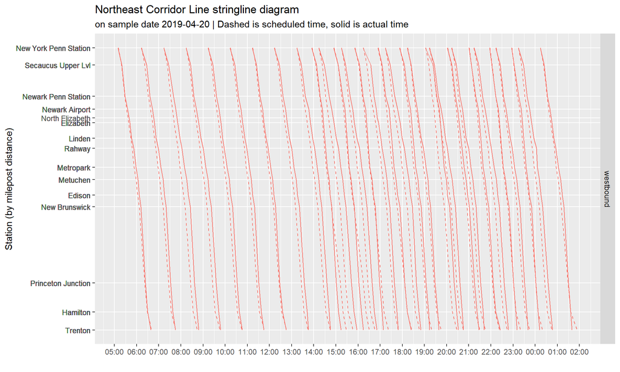

```r
oneday <- njtlines %>% ungroup() %>% filter(line == "Northeast Corrdr" & date %in% slice_sample(.)) %>%
  mutate(to.dist.mp=to.dist.mp*-1)

oneday %>%
  ggplot(aes(y=to.dist.mp,group=train_id,color=direction)) +
    geom_line(aes(x=scheduled_time),linetype='dashed',lwd=.50) +
    geom_line(aes(x=actual_time),lwd=.50) +
    scale_y_continuous(breaks = oneday$to.dist.mp, labels = oneday$to, minor_breaks = NULL) +
    scale_x_datetime(date_breaks = "1 hour", labels = date_format("%H:%M")) +
    labs(x='',y='Station (by milepost distance)',
         title="Northeast Corridor Line stringline diagram",
         subtitle=paste("on sample date",oneday$date,"| Dashed is scheduled time, solid is actual time")) +
    theme(legend.position='none') +
    facet_grid(rows=vars(direction))
```

## Feature engineering

### Weather

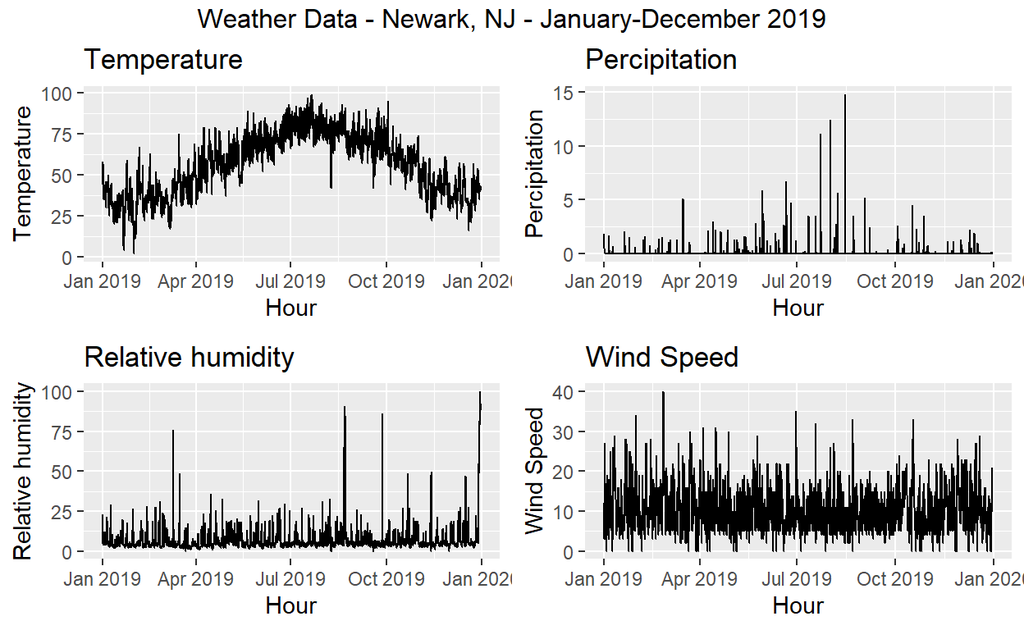

```r
weather.DataNWK <-
  riem_measures(station = "EWR", date_start = "2019-01-01", date_end = "2019-12-31")

weather.PanelNWK <-
  weather.DataNWK %>%
  mutate_if(is.character, list(~replace(as.character(.), is.na(.), "0"))) %>%
  replace(is.na(.), 0) %>%
  mutate(interval60 = ymd_h(substr(valid, 1, 13))) %>%
  mutate(week = week(interval60),
         dotw = wday(interval60, label=TRUE)) %>%
  group_by(interval60) %>%
  summarize(Temperature = max(tmpf),
            Precipitation = sum(p01i),
            Rel_Humidity = mean(relh),
            Wind_Speed = max(sknt)) %>%
  mutate(Temperature = ifelse(Temperature == 0, 42, Temperature))

grid.arrange(top = "Weather Data - Newark, NJ - January-December 2019",
             ggplot(weather.PanelNWK, aes(interval60,Temperature)) + geom_line() +
               labs(title="Temperature", x="Hour", y="Temperature"),
             ggplot(weather.PanelNWK, aes(interval60,Precipitation)) + geom_line() +
               labs(title="Percipitation", x="Hour", y="Percipitation"),
             ggplot(weather.PanelNWK, aes(interval60,Rel_Humidity)) + geom_line() +
               labs(title="Relative humidity", x="Hour", y="Relative humidity"),
             ggplot(weather.PanelNWK, aes(interval60,Wind_Speed)) + geom_line() +
               labs(title="Wind Speed", x="Hour", y="Wind Speed"))
```

```r
njtlines <- njtlines %>%
  mutate(interval30 = floor_date(scheduled_time, unit = "30min"),
         interval60 = floor_date(scheduled_time, unit = "hour"),
         week = week(scheduled_time),
         dotw = wday(scheduled_time),
         trip_count = 1) %>%
  left_join(weather.PanelNWK, by = "interval60")%>%
  na.omit()
```

### Cancelled trains data

One open data set from NJT is particularly valuable: cancellations by month categorized by reason. This is a direct test of the theory that knock-on disruptions to one train can propagate into other trains close in time.

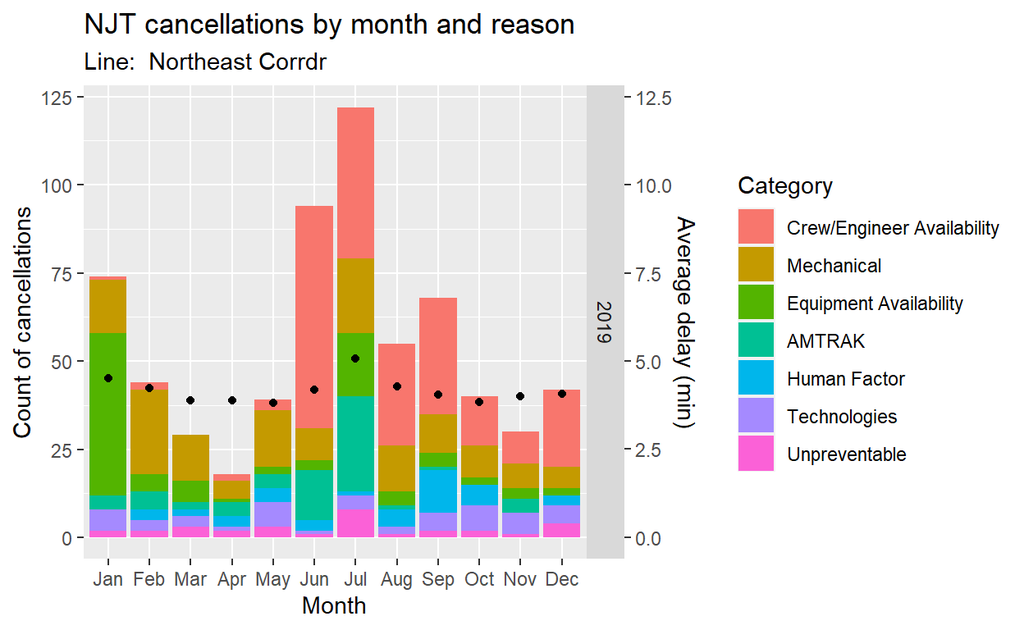

```r
cancel <- bind_rows(
  read_csv("cancel/RAIL_ACRL_CANCELLATIONS_DATA.csv") %>% mutate(line="Atl. City Line"),
  read_csv("cancel/RAIL_BNTN_CANCELLATIONS_DATA.csv") %>% mutate(line="Bergen Co. Line"),
  read_csv("cancel/RAIL_MNBN_CANCELLATIONS_DATA.csv") %>% mutate(line="Montclair-Boonton"),
  read_csv("cancel/RAIL_MNE_CANCELLATIONS_DATA.csv") %>% mutate(line="Morristown Line"),
  read_csv("cancel/RAIL_NEC_CANCELLATIONS_DATA.csv") %>% mutate(line="Northeast Corrdr"),
  read_csv("cancel/RAIL_NJCL_CANCELLATIONS_DATA.csv") %>% mutate(line="No Jersey Coast"),
  read_csv("cancel/RAIL_PASC_CANCELLATIONS_DATA.csv") %>% mutate(line="Pascack Valley"),
  read_csv("cancel/RAIL_RARV_CANCELLATIONS_DATA.csv") %>% mutate(line="Raritan Valley"),
  ) %>% filter(YEAR %in% c(2019)) %>% mutate(CANCEL_COUNT = as.numeric(CANCEL_COUNT),CANCEL_TOTAL = as.numeric(CANCEL_TOTAL))

delayByMonth <- njtlines %>%
  group_by(line,year(date),month(date,abbr=T)) %>% summarise(meanDelay = mean(delay_minutes)) %>%
  rename('YEAR'='year(date)','MONTH'='month(date, abbr = T)')

ggplot() +
  geom_bar(data=filter(cancel,line=="Northeast Corrdr"),
           aes(fill=reorder(CATEGORY,-CANCEL_COUNT),
               x=factor(str_sub(str_to_sentence(filter(cancel,line=="Northeast Corrdr")$MONTH),1,3),level=month.abb),
               y=CANCEL_COUNT),
           position="stack",stat="identity") +
  geom_point(data=filter(delayByMonth,line=="Northeast Corrdr"), aes(x=MONTH,y=meanDelay*10)) +
  scale_fill_discrete(name='Category') +
  scale_y_continuous(sec.axis=sec_axis(trans=~./10,name='Average delay (min)')) +
  labs(title='NJT cancellations by month and reason',
       subtitle=paste("Line: ",filter(cancel,line=="Northeast Corrdr")$line),
       x='Month', y='Count of cancellations') +
  facet_grid(rows=vars(YEAR))
```

```r
cancel <- cancel %>% select(-CANCEL_PERCENTAGE) %>%
  pivot_wider(names_from=CATEGORY,values_from=CANCEL_COUNT) %>%
  rename(crewAvail = `Crew/Engineer Availability`,
         equipAvail = `Equipment Availability`,
         humanFactor = `Human Factor`,
         infraEng = `Infrastructure Engineering`)

njtlines <- njtlines %>% mutate(YEAR=as.character(year(date)),MONTH=str_to_upper(month(date, label=T, abbr=F))) %>%
  left_join(cancel,by=c('line','YEAR','MONTH')) %>% mutate_if(is.numeric,coalesce,0) %>%
  mutate(MONTH = factor(str_to_sentence(MONTH), level=month.name),
         to_id = as.character(to_id),from_id = as.character(from_id))
```

### Geographic view of station delay

Plotting average station delay at each station allows us to visualize more concretely how delays are playing out on a larger scale.

```r
# njgin.line <- st_read("https://opendata.arcgis.com/datasets/e6701817be974795aecc7f7a8cc42f79_0.geojson")
# njgin.station <- st_read("https://opendata.arcgis.com/datasets/4809dada94c542e0beff00600ee930f6_0.geojson")
```

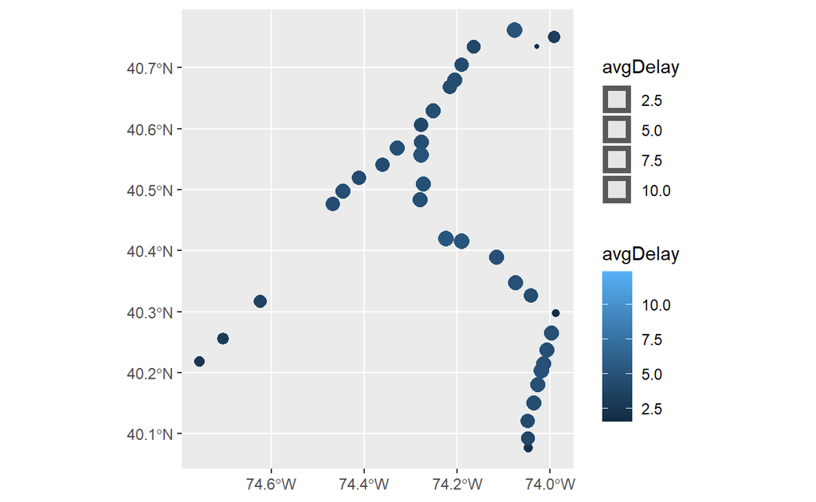

```r
njtlines %>% left_join(dplyr::select(njt_sf$stops,stop_id,zone_id,geometry),by=c("to_id"="stop_id")) %>%
  st_as_sf() %>% filter(isWkdy) %>% group_by(to) %>%
  summarise(avgDelay=mean(delay_minutes)) %>%
  ggplot() + geom_sf(aes(color=avgDelay,size=avgDelay))
```

## Regression model building and training

We introduce the time lag into our predictor set, with several intervals: 30 minutes, 1/1.5/2/3/12 hours, and one day. The correlation coefficients show that the lags up to 3 hours have reasonably high correlation.

```r
njtlines <- njtlines %>% ungroup() %>%
  arrange(from,interval30) %>%
  mutate(lag30Min = dplyr::lag(delay_minutes,1),
         lag1Hour = dplyr::lag(delay_minutes,2),
         lag90Min = dplyr::lag(delay_minutes,3),
         lag2Hour = dplyr::lag(delay_minutes,4),
         lag3Hour = dplyr::lag(delay_minutes,6),
         lag12Hour = dplyr::lag(delay_minutes,24),
         lag1Day = dplyr::lag(delay_minutes,48)
  )
```

```r
as.data.frame(njtlines) %>%
    group_by(interval30) %>%
    summarise_at(vars(starts_with("lag"), "delay_minutes"), mean, na.rm = TRUE) %>%
    gather(Variable, Value, -interval30, -delay_minutes) %>%
    mutate(Variable = factor(Variable, levels=c("lag30Min","lag1Hour","lag90Min","lag2Hour",
                                                "lag3Hour","lag12Hour","lag1Day")))%>%
    group_by(Variable) %>%
    summarize(correlation = round(cor(Value, delay_minutes),2))
```

```
# A tibble: 8 x 2
  Variable  correlation
  <fct>           <dbl>
1 lag30Min         0.68
2 lag1Hour         0.55
3 lag90Min         0.51
4 lag2Hour         0.44
5 lag3Hour         0.31
6 lag12Hour        0.17
7 lag1Day          0.09
8 <NA>             0.94
```

### Correlation matrix

Compiling the correlation matrix shows the relationship between all predictors to the response variable, *delay_minutes*, and each other.

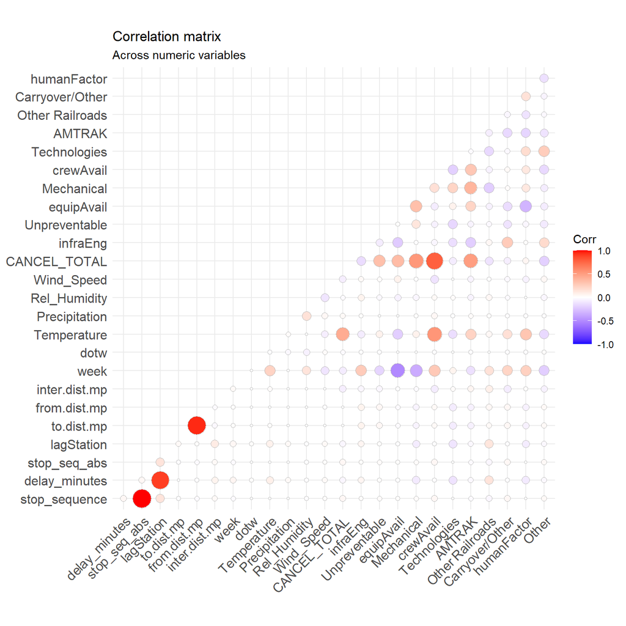

```r
njtlines %>% select_if(is.numeric) %>%
  cor() %>% ggcorrplot(type="lower", method="circle") +
  scale_size_continuous(range=c(1,8),) +
  labs(title = "Correlation matrix",
       subtitle = "Across numeric variables")
```

### Model building

```r
njtlines <- njtlines %>% mutate(logDelay = log(delay_minutes + 0.1))

delay.Train <- filter(njtlines, date < ymd(20190801))
delay.Test <- filter(njtlines, date >= ymd(20190801))
```

Our model uses a total of nineteen predictors, after repeated evaluation of predictor strength: - Categorical: line, to(station), time period, direction, - Numeric: Wind speed, total cancelled trains, trains cancelled for Amtrak, crew availability, equipment availability, mechanical issues, inter-station distance, delay lag by previous station, time lags 30 min/1/1.5/2/3/12 hours - Binary: is Weekday train

```r
fit <- lm(logDelay ~ line + to + period + isWkdy + direction + Wind_Speed +
            CANCEL_TOTAL + AMTRAK + crewAvail +
            equipAvail + Mechanical + inter.dist.mp + lagStation +
            lag30Min + lag1Hour + lag90Min + lag2Hour + lag3Hour + lag12Hour,
          data=delay.Train)

f <- predict(fit, delay.Test)
Test <- bind_cols(delay.Test, as_tibble(f)) %>%
          rename(Delay.Predict = value) %>%
          mutate(Delay.Error = Delay.Predict - delay_minutes,
               Delay.AbsError = abs(Delay.Predict - delay_minutes),
               Delay.APE = (abs(Delay.Predict - delay_minutes)) / Delay.Predict)
mae <- mean(Test$Delay.AbsError, na.rm=TRUE)
mape <- mean(Test$Delay.APE, na.rm=TRUE)
```

```r
stargazer::stargazer(fit, type='html', align=TRUE, no.space=TRUE)
```

|  | *Dependent variable:* |
| --- | --- |
|  | logDelay |
| lineNo Jersey Coast | 1.328*** |
|  | (0.032) |
| lineNortheast Corrdr | 1.433*** |
|  | (0.033) |
| toAbsecon | -0.388*** |
|  | (0.042) |
| toAllenhurst | 0.195*** |
|  | (0.021) |
| toAsbury Park | 0.082*** |
|  | (0.021) |
| toAtco | -0.578*** |
|  | (0.042) |
| toAtlantic City Rail Terminal | 0.185*** |
|  | (0.042) |
| toAvenel | -0.188*** |
|  | (0.026) |
| toBay Head | -1.184*** |
|  | (0.021) |
| toBelmar | 0.196*** |
|  | (0.021) |
| toBradley Beach | 0.191*** |
|  | (0.021) |
| toCherry Hill | -0.482*** |
|  | (0.042) |
| toEdison | -0.235*** |
|  | (0.016) |
| toEgg Harbor City | -0.348*** |
|  | (0.042) |
| toElberon | 0.462*** |

[output cut: 110 more lines]

### Predictions on test data

Our model results are promising, with the best predictive power being the model including the time lags. The mean absolute error for the test set by week is around 0.9 minutes, but cross-validated by hour of week, the distribution peaks at 0.1 minutes.

```r
delay.Test.weekNest <-
  delay.Test %>%
  nest(-week)
```

```r
model_pred <- function(dat, fit){
   pred <- predict(fit, newdata = dat)}
```

```r
week_predictions <-
  delay.Test.weekNest %>%
    mutate(model = map(.x = data, fit = fit, .f = model_pred)) %>%
    gather(Regression, Prediction, -data, -week) %>%
    mutate(Observed = map(data, pull, logDelay),
           Absolute_Error = map2(Observed, Prediction, ~ abs(.x - .y)),
           MAE = map_dbl(Absolute_Error, mean, na.rm = TRUE),
           sd_AE = map_dbl(Absolute_Error, sd, na.rm = TRUE))
```

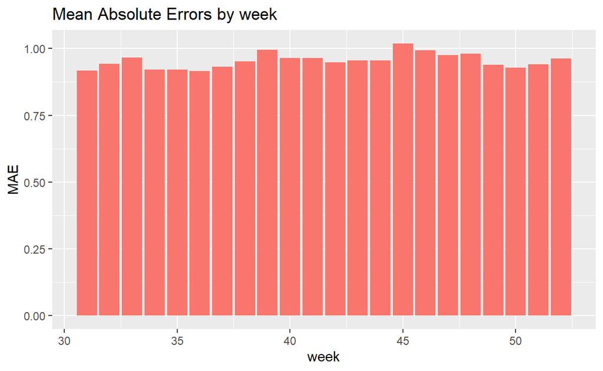

```r
week_predictions %>%
  dplyr::select(week, Regression, MAE) %>%
  gather(Variable, MAE, -Regression, -week) %>%
  ggplot(aes(week, MAE)) +
    geom_bar(aes(fill = Regression), position = "dodge", stat="identity") +
    labs(title = "Mean Absolute Errors by week") + theme(legend.position='none')
```

When we plot the predicted average delay against the observed delay, we notice that while “regular” periodic small delays of 4 minutes of less are well-predicted against, large delays of 7 minutes or more are more intermittently anticipated and predicted.

[figure not shown]

```r
week_predictions %>%
    mutate(interval30 = map(data, pull, interval30),
           from = map(data, pull, from),
           direction = map(data,pull,direction)) %>%
    dplyr::select(interval30, from, direction, Observed, Prediction, Regression) %>%
    unnest(cols = c(interval30, from, direction, Observed, Prediction)) %>%
    gather(Variable, Value, -Regression, -interval30, -from, -direction) %>%
    group_by(Regression, Variable, interval30, direction) %>%
    summarize(Value = mean(Value)) %>%
    filter(week(interval30) > 45) %>%
    ggplot(aes(interval30, exp(Value)-0.1, colour=Variable)) +
      geom_line(size = 0.5) +
      facet_wrap(~direction, ncol=1) +
      labs(title = "Predicted/Observed delay time series",
           subtitle = "Test set of three weeks",  x = "Datetime", y= "Delay (minutes)") +
    theme(legend.position='bottom') +
    coord_cartesian(ylim=c(0,15))
```

## Cross-validation

In linear models, is is always important to repeat predictions on test data on multiple dimensions, known as cross-validation. If the initial accuracy found above holds for these additional dimensions, then we can say the model has a high degree of *generalizblity* and is not badly overfit onto this specific instance of training data. Incorporating cross-validation across space and time will help us understand where and how our predictions are holding up.

```r
crossValidate <- function(dataset, id, dependentVariable, indVariables) {

  allPredictions <- data.frame()
  cvID_list <- unique(dataset[[id]])

  for (i in cvID_list) {

    thisFold <- i

    fold.train <- filter(dataset, dataset[[id]] != thisFold) %>% as.data.frame() %>%
      dplyr::select(all_of(id), all_of(indVariables), all_of(dependentVariable))
    fold.test  <- filter(dataset, dataset[[id]] == thisFold) %>% as.data.frame() %>%
      dplyr::select(all_of(id), all_of(indVariables), all_of(dependentVariable))

    regression <-
      glm(paste0(dependentVariable,"~ ."), family = "gaussian",
          data = dplyr::select(fold.train,-id))

    thisPrediction <-
      mutate(fold.test, Prediction = predict(regression, fold.test, type = "response"))

    allPredictions <-
      rbind(allPredictions, thisPrediction)

  }
  return(allPredictions)
}
```

```r
reg.vars <- word(str_sub(str_replace_all(toString(fit$terms[[3]]),'\\,', ' +'),5),1:19,sep=fixed(" + "))

reg.cv.time <- crossValidate(
  dataset = delay.Test %>% mutate(day.hour = paste(dotw,hour(interval60)),
                                  isWkdy = ifelse(wday(interval60) %in% c(2,3,4,5,6),TRUE,FALSE)),
  id = "day.hour",
  dependentVariable = "logDelay",
  indVariables = reg.vars) %>%
  dplyr::select(isWkdy, day.hour, logDelay, Prediction)

reg.cv.station <- crossValidate(
  dataset = delay.Test,
  id = "to",
  dependentVariable = "logDelay",
  indVariables = reg.vars) %>%
  dplyr::select(to, logDelay, Prediction)
```

### Cross-validation by time

When cross-validated by time, we can see the the MAE is significantly minimized to near-zero; however there are a few large spikes that persist

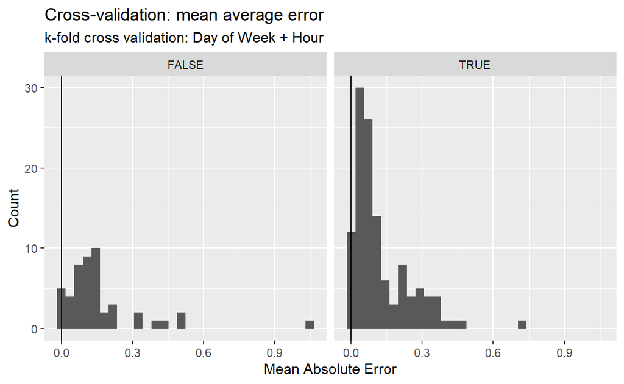

```r
reg.cv.time %>%
 group_by(isWkdy,day.hour) %>%
  summarize(Mean_Error = mean(Prediction - logDelay, na.rm = T),
            MAE = mean(abs(Mean_Error), na.rm = T)) %>%
  ungroup() %>%
  ggplot() +
    geom_histogram(aes(MAE), bins = 30) +
    geom_vline(xintercept = 0) +
    labs(title="Cross-validation: mean average error", subtitle = "k-fold cross validation: Day of Week + Hour",
         x="Mean Absolute Error", y="Count") +
  facet_wrap(vars(isWkdy))
```

### Cross-validation by space (station)

For CV by station, we see notable spikes in errors at terminal stations, where trains start their run later than scheduled, as well as at the mid-points of lines like the North Jersey Coast Line that continues outward. These can be chalked up to more particular operational quirks that currently do not have any relevant open-facing data attached to them.

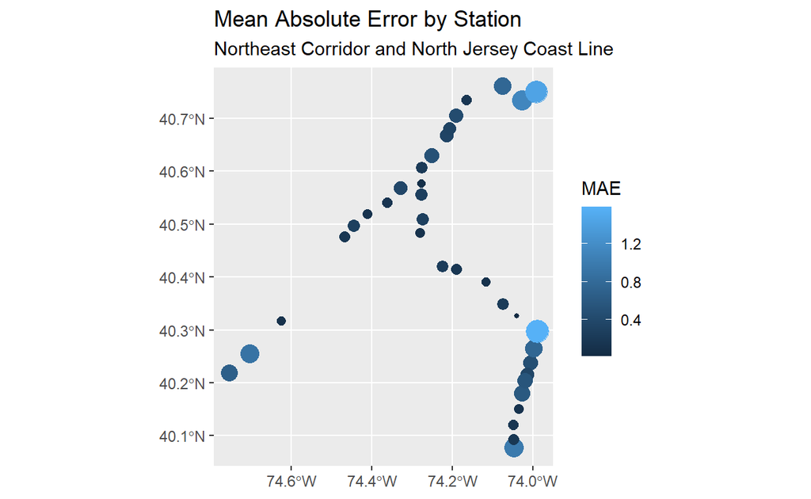

```r
reg.cv.station %>%
  group_by(to) %>%
  summarize(Mean_Error = mean(Prediction - logDelay, na.rm = T),
            MAE = mean(abs(Mean_Error), na.rm = T)) %>%
  ungroup() %>% left_join(njtlines %>% filter(date %in% slice_sample(.)) %>% distinct(to,to_id),by='to') %>%
  left_join(dplyr::select(njt_sf$stops,stop_id,zone_id,geometry),by=c("to_id"="stop_id")) %>% st_as_sf() %>%
  ggplot() +
  geom_sf(aes(color=MAE,size=MAE)) + scale_size_continuous(guide=F) +
  labs(title='Mean Absolute Error by Station',
       subtitle='Northeast Corridor and North Jersey Coast Line')
```

## Conclusion

However, at this stage we are beginning to see the limits of solely relying on public-facing data, especially in the context of a relatively closed system such as transit. As a system, transit has fewer external socioeconomic factors that are frequently and abundantly captured in open data; on the contrary, most data are captive to the department or division that directly captured it for internal purposes only. Nominally, there is indeed little reason why any given person would want data on known trackage bottlenecks, rolling stock performance figures, dispatch accuracy (particularly important for start of runs!) trip-level passenger boarding data, and thousands of other possible data points. We can point out certain factors relatively easily, whether because of bottlenecks on physical trackage; but not being able to to predict Amtrak dispatchers that actually control the traffic, and other incidents like mechanical issues, passenger-related delays. Thus, working directly with NJ Transit Operations and Maintenance personnel and sharing this previously isolated data may help us to understand delays on a more sophisticated level.

In addition, there is still the distinct possibility that any seemingly random or spontaneous factor could affect delays at any time, too rapid or too abstract to quantify for use in this model. June 2019’s labor disruptions was an example, as is the continuing pandemic and the effects it has on overall ridership, particularly on known bottlenecks such as boarding at terminal stations. Very likely, delays as a matter of pure passenger operations will continue to minimize at peak hours, and perhaps persist in off-peak hours if customers shift towards riding off-peak. The pandemic has not only shifted ridership, but fundamentally how NJ Transit’s workforce and operations might perhaps be operated on a daily basis, and this needs to be anticipated as well.

Future steps to be taken with this model abound. As said, the pandemic makes all pre-2020 data somewhat outdated in retrospect, and this model will have to be repeated through at least a full year in 2021 if immediate utility is to be prioritized. Secondly, expanding this model across all lines can be possible with more computing power and memory. In addition, delay interactions with other modes should be explored: Amtrak’s presence on the Northeast Corridor alone is a major factor, as trains there are actually all dispatched by Amtrak staff and Amtrak trains are usually prioritized. Integrating the possibilty of bus and light rail connections, both on NJT and neighboring systems, could be interesting to see if intermodal transfers are already being affected through delays on the single system of commuter rail. And lastly, it is of great interest to model scenarios where potential disruptive interventions, such as a new Hudson River Tunnel, could minimize delays to a quantifiable and definitive extent. Knowing exactly how much any given rider’s commute could be improved through investments makes it a powerful tool for advocates and politicians to argue for them, to ensure the continued operating stability and growth of NJ Transit and all transit agencies.